# 431 Class 03

Thomas E. Love, Ph.D.

2024-09-03

## Today’s Agenda

- Work in R with a familiar data set (the 15 question “quick survey” from Class 02)
- Open RStudio, load in some data and a template to write Quarto code
  - We’ll do a little typing into the template today, but just a little.
    - We’ll then look at the completed Quarto document.
    - We’ll also inspect and knit the Quarto file after all of the code is included.
  - Then we’ll start over again with the slides.

These slides walk through everything in that Quarto document.

## Today’s Files

From our [431-data page](https://github.com/THOMASELOVE/431-data), or our [Class 03 README (data folder)](https://github.com/THOMASELOVE/431-classes-2024/tree/main/class03/data), you should find:

- `431-first-r-template.qmd`
- `quick_survey_2024.csv`

and

- `431-class03-all-code.qmd`

in addition to the usual slide materials.

## Today’s Plan

We’re using Quarto to gather together into a single document:

- the code we build,
- text commenting on and reacting to that code, and
- the output of the analyses we build.

Everything in these slides is also going into our Quarto file.

## Load packages and set theme

```r
library(janitor)
library(patchwork)
library(easystats)
library(tidyverse)

theme_set(theme_bw())
knitr::opts_chunk$set(comment = NA)
```

Loading packages in R is like opening up apps on your phone. We need to tell R that, in addition to the base functions available in the software, we also have other functions we want to use.

- Why are we loading these packages, in particular?

## On the tidyverse meta-package

- We will use the series of packages called the `tidyverse` in every Quarto file we create.
  - The `tidyverse` was developed (in part) by Hadley Wickham, Chief Scientist at Posit (makers of RStudio).
  - `dplyr` for data wrangling, cleaning and transformation
  - `ggplot2` is our main visualization package
  - other `tidyverse` packages help import data, work with factors and other common activities.

## More on today’s packages

- The `janitor` package has some tools for examining, cleaning and tabulating data (including `tabyl()` and `clean_names()`) that we’ll use regularly.
- The `patchwork` package will help us show multiple `ggplots` together.
- The `easystats` meta-package contains several other packages that will help us (especially) with building models and presenting our results.
- It’s helpful to load the `tidyverse` package last.

## Today’s Data

Our data come from the Quick 15-item Survey we did in Class 02 ([pdf in Class 02 README](https://github.com/THOMASELOVE/431-classes-2024/blob/main/class02/431_surveyhandout_1perstudent_2024-08-29.pdf)), which we’ve done (in various forms) since 2014.

- A copy of these data (in .csv format) is on our [431-data page](https://github.com/THOMASELOVE/431-data), and also linked on our [Class 03 README](https://github.com/THOMASELOVE/431-classes-2024/tree/main/class03/data).

We’ll tackle several exploratory questions of interest…

## Read in data from `.csv` file

```r
quicksur_raw <-
  read_csv("c03/data/quick_survey_2024.csv", show_col_types = FALSE) |>
  janitor::clean_names()
```

- The `<-` assignment arrow creates `quicksur_raw`
- We use `read_csv` to read in data from the `c03/data` subfolder of my R project directory which contains the `quick_survey_2024.csv` file from our [431-data page](https://github.com/THOMASELOVE/431-data).
- We use `show_col_types = FALSE` to suppress some unnecessary output describing the column types
- We use `clean_names()` from the janitor package
- Note the use of the pipe `|>` to direct the information flow

## What is the result?

```r
dim(quicksur_raw)
```

```
[1] 603  23
```

```r
quicksur_raw
```

```
# A tibble: 603 × 23
   student glasses english statsofar love_htcm smoke h_left h_right handedness
     <dbl> <chr>   <chr>       <dbl>     <dbl> <dbl>  <dbl>   <dbl>      <dbl>
 1  202401 n       y               5       175     1     16       1      -0.88
 2  202402 y       y               3       180     1      3      10       0.54
 3  202403 y       y               2       183     1      0      10       1
 4  202404 y       n               7       188     1      8      10       0.11
 5  202405 n       y               5       183     1      1      15       0.88
 6  202406 y       y               3       185     1      1      14       0.87
 7  202407 n       y               4       183     1      2      15       0.76
 8  202408 n       y               7       188     1      6      14       0.4
 9  202409 y       n               7       188     1      8      10       0.11
10  202410 n       y               5       191     1      1      12       0.85
# ℹ 593 more rows
# ℹ 14 more variables: statfuture <dbl>, haircut <dbl>, lecture <dbl>,
#   alone <dbl>, height_in <dbl>, hand_span <dbl>, favcolor <chr>,
#   lastsleep <dbl>, pulse <dbl>, year <dbl>, lovetrueage <dbl>,
#   lovetrueht <dbl>, sex <chr>, ageguess <dbl>
```

## A more detailed look?

```r
glimpse(quicksur_raw)
```

```
Rows: 603
Columns: 23
$ student     <dbl> 202401, 202402, 202403, 202404, 202405, 202406, 202407, 20…
$ glasses     <chr> "n", "y", "y", "y", "n", "y", "n", "n", "y", "n", "y", "n"…
$ english     <chr> "y", "y", "y", "n", "y", "y", "y", "y", "n", "y", "y", "y"…
$ statsofar   <dbl> 5, 3, 2, 7, 5, 3, 4, 7, 7, 5, 6, 3, 5, 6, 3, 5, 5, 6, 4, 5…
$ love_htcm   <dbl> 175, 180, 183, 188, 183, 185, 183, 188, 188, 191, 178, 180…
$ smoke       <dbl> 1, 1, 1, 1, 1, 1, 1, 1, 1, 1, 1, 1, 1, 1, 1, 1, 1, 1, 1, 1…
$ h_left      <dbl> 16, 3, 0, 8, 1, 1, 2, 6, 8, 1, 15, 16, 1, 1, 14, 19, 3, 1,…
$ h_right     <dbl> 1, 10, 10, 10, 15, 14, 15, 14, 10, 12, 10, 10, 18, 15, 10,…
$ handedness  <dbl> -0.88, 0.54, 1.00, 0.11, 0.88, 0.87, 0.76, 0.40, 0.11, 0.8…
$ statfuture  <dbl> 7, 7, 7, 7, 7, 6, 5, 7, 7, 6, 7, 5, 7, 7, 6, 6, 6, 3, 7, 5…
$ haircut     <dbl> 50, 30, 80, 10, 45, 45, 130, 60, 40, 37, 12, 40, 176, 10, …
$ lecture     <dbl> 3, 5, 3, 2, 2, 3, 3, 3, 3, 2, 2, 3, 3, 3, 2, 5, 3, 2, 4, 4…
$ alone       <dbl> 3, 3, 2, 5, 3, 5, 5, 5, 5, 3, 2, 3, 4, 4, 2, 5, 4, 5, 3, 4…
$ height_in   <dbl> 63.00, 69.00, 66.00, 68.50, 62.00, 64.00, 76.00, 72.00, 67…
$ hand_span   <dbl> 15.0, 20.5, 20.5, 20.0, 14.5, 18.0, 22.0, 21.5, 22.0, 18.5…
$ favcolor    <chr> "purple", "blue", "green", "yellow", "yellow", "green", "g…
$ lastsleep   <dbl> 8.5, 10.0, 5.0, 5.0, 8.0, 8.0, 7.0, 6.0, 6.0, 5.5, 5.5, 5.…
$ pulse       <dbl> 75, 74, 90, 70, 80, 99, 70, 72, 64, 76, 80, 92, 88, 80, 88…
$ year        <dbl> 2024, 2024, 2024, 2024, 2024, 2024, 2024, 2024, 2024, 2024…
$ lovetrueage <dbl> 57.5, 57.5, 57.5, 57.5, 57.5, 57.5, 57.5, 57.5, 57.5, 57.5…
$ lovetrueht  <dbl> 188, 188, 188, 188, 188, 188, 188, 188, 188, 188, 188, 188…
$ sex         <chr> NA, NA, NA, NA, NA, NA, NA, NA, NA, NA, NA, NA, NA, NA, NA…
$ ageguess    <dbl> NA, NA, NA, NA, NA, NA, NA, NA, NA, NA, NA, NA, NA, NA, NA…
```

## Counting Categories

```r
quicksur_raw |> count(glasses)
```

```
# A tibble: 3 × 2
  glasses     n
  <chr>   <int>
1 n         125
2 y         222
3 <NA>      256
```

```r
quicksur_raw |> count(glasses, english)
```

```
# A tibble: 9 × 3
  glasses english     n
  <chr>   <chr>   <int>
1 n       n          29
2 n       y          95
3 n       <NA>        1
4 y       n          47
5 y       y         173
6 y       <NA>        2
7 <NA>    n          47
8 <NA>    y         205
9 <NA>    <NA>        4
```

## Favorite Color in 2024?

```r
quicksur_raw |>
    filter(year == "2024") |>
    tabyl(favcolor) |>
    adorn_pct_formatting()
```

```
     favcolor  n percent valid_percent
    baby pink  2    3.6%          3.7%
        black  1    1.8%          1.9%
         blue 17   30.4%         31.5%
     burgundy  1    1.8%          1.9%
        green 17   30.4%         31.5%
 hunter green  1    1.8%          1.9%
       maroon  1    1.8%          1.9%
         pink  1    1.8%          1.9%
  pink-orange  1    1.8%          1.9%
       purple  5    8.9%          9.3%
          red  1    1.8%          1.9%
    turquoise  1    1.8%          1.9%
       yellow  5    8.9%          9.3%
         <NA>  2    3.6%             -
```

## Using `summary()` on Quantities

```r
quicksur_raw |>
  select(love_htcm, haircut, height_in, lastsleep) |>
  summary()
```

```
   love_htcm        haircut         height_in      lastsleep
 Min.   :152.0   Min.   :  0.00   Min.   :57.0   Min.   : 2.000
 1st Qu.:178.0   1st Qu.: 13.50   1st Qu.:64.0   1st Qu.: 6.000
 Median :183.0   Median : 25.00   Median :67.0   Median : 7.000
 Mean   :181.9   Mean   : 31.47   Mean   :67.2   Mean   : 6.909
 3rd Qu.:185.0   3rd Qu.: 40.00   3rd Qu.:70.0   3rd Qu.: 8.000
 Max.   :196.0   Max.   :250.00   Max.   :77.5   Max.   :12.000
 NA's   :385     NA's   :12       NA's   :9      NA's   :8
```

- Numerical summaries (five quantiles, plus the mean) for:
  - your guess of my height (in cm), last haircut price ($), your height (in inches), and last night’s hours of sleep
- How many observations are available for these measures?

# Manage the data into an analytic tibble called `qsdat`

## Variables we’ll look at closely today

We’ll place these seven variables into our analytic data frame (tibble.)

- `student`: student identification (numerical code)
- `year`: indicates year when survey was taken (August)
- `english`: y = prefers to speak English, else n
- `smoke`: 1 = never smoker, 2 = quit, 3 = current
- `pulse`: pulse rate (beats per minute)
- `height_in`: student’s height (in inches)
- `haircut`: price of student’s last haircut (in $)

## Select our variables

```r
qsdat <- quicksur_raw |>
    select(student, year, english, smoke,
           pulse, height_in, haircut)
```

- The `select()` function chooses the variables (columns) we want to keep in our new tibble called `qsdat`.
- What should the result of this code look like?

## What do we have now?

```r
dim(qsdat)
```

```
[1] 603   7
```

```r
qsdat
```

```
# A tibble: 603 × 7
   student  year english smoke pulse height_in haircut
     <dbl> <dbl> <chr>   <dbl> <dbl>     <dbl>   <dbl>
 1  202401  2024 y           1    75      63        50
 2  202402  2024 y           1    74      69        30
 3  202403  2024 y           1    90      66        80
 4  202404  2024 n           1    70      68.5      10
 5  202405  2024 y           1    80      62        45
 6  202406  2024 y           1    99      64        45
 7  202407  2024 y           1    70      76       130
 8  202408  2024 y           1    72      72        60
 9  202409  2024 n           1    64      67        40
10  202410  2024 y           1    76      60        37
# ℹ 593 more rows
```

## Initial Numeric Summaries

- Is everything the “type” of variable it should be?
- Are we getting the summaries we want?

```r
summary(qsdat)
```

```
    student            year        english              smoke
 Min.   :201401   Min.   :2014   Length:603         Min.   :1.000
 1st Qu.:201661   1st Qu.:2016   Class :character   1st Qu.:1.000
 Median :201948   Median :2019   Mode  :character   Median :1.000
 Mean   :201944   Mean   :2019                      Mean   :1.088
 3rd Qu.:202213   3rd Qu.:2022                      3rd Qu.:1.000
 Max.   :202456   Max.   :2024                      Max.   :3.000
                                                    NA's   :2
     pulse          height_in       haircut
 Min.   : 30.00   Min.   :57.0   Min.   :  0.00
 1st Qu.: 65.00   1st Qu.:64.0   1st Qu.: 13.50
 Median : 72.00   Median :67.0   Median : 25.00
 Mean   : 73.93   Mean   :67.2   Mean   : 31.47
 3rd Qu.: 80.00   3rd Qu.:70.0   3rd Qu.: 40.00
 Max.   :112.00   Max.   :77.5   Max.   :250.00
 NA's   :79       NA's   :9      NA's   :12
```

## What should we be seeing?

- Categorical variables should list the categories, with associated counts.
  - To accomplish this, the variable needs to be represented in R with a `factor`, rather than as a `character` or `numeric` variable.
- Quantitative variables should show the minimum, median, mean, maximum, etc.

```r
names(qsdat)
```

```
[1] "student"   "year"      "english"   "smoke"     "pulse"     "height_in"
[7] "haircut"
```

## Categorical variables as factors

We want the `year` and `smoke` information treated as categorical, rather than as quantitative, and the `english` information as a factor, too. Also, do we want to summarize the student ID codes?

- We use the `mutate()` function to help with this.

```r
qsdat <- qsdat |>
    mutate(year = as_factor(year),
           smoke = as_factor(smoke),
           english = as_factor(english),
           student = as.character(student))
```

- Note that it’s `as_factor()` but `as.character()`. Sigh.

## Next step: Recheck the summaries and do range checks

- Do these summaries make sense?
- Are the minimum and maximum values appropriate?
- How much missingness are we to deal with?

## Now, how’s our summary?

```r
summary(qsdat)
```

```
   student               year     english     smoke         pulse
 Length:603         2020   : 67   y   :473   1   :558   Min.   : 30.00
 Class :character   2016   : 64   n   :123   2   : 33   1st Qu.: 65.00
 Mode  :character   2019   : 61   NA's:  7   3   : 10   Median : 72.00
                    2021   : 58              NA's:  2   Mean   : 73.93
                    2024   : 56                         3rd Qu.: 80.00
                    2022   : 54                         Max.   :112.00
                    (Other):243                         NA's   :79
   height_in       haircut
 Min.   :57.0   Min.   :  0.00
 1st Qu.:64.0   1st Qu.: 13.50
 Median :67.0   Median : 25.00
 Mean   :67.2   Mean   : 31.47
 3rd Qu.:70.0   3rd Qu.: 40.00
 Max.   :77.5   Max.   :250.00
 NA's   :9      NA's   :12
```

- Some things to look for appear on the next slide.

## What to look for…

- Are we getting counts for all variables that are categorical?
  - Do the category levels make sense?
- Are we getting means and medians for all variables that are quantities?
  - Do the minimum and maximum values make sense for each of these quantities?
- Which variables have missing data, as indicated by `NA's`?

## The summary for `year` is an issue

- Just to fill in the gap left by the `summary()` result, how many students responded each year?

```r
qsdat |> tabyl(year) |> adorn_totals() |> adorn_pct_formatting()
```

```
  year   n percent
  2014  42    7.0%
  2015  49    8.1%
  2016  64   10.6%
  2017  48    8.0%
  2018  51    8.5%
  2019  61   10.1%
  2020  67   11.1%
  2021  58    9.6%
  2022  54    9.0%
  2023  53    8.8%
  2024  56    9.3%
 Total 603  100.0%
```

## Five Questions of (some) Interest

1. What is the distribution of pulse rates among students in 431 since 2014?
2. Does the distribution of student heights change materially over time?
3. Is the Normal distribution a good model for student heights? How about student haircut prices?
4. Do taller people appear to have paid less for their most recent haircut?
5. Do students have a more substantial tobacco history if they prefer to speak English or a language other than English?

## Question 1

What is the distribution of pulse rates among students in 431 since 2014?

```r
qsdat |> tabyl(pulse)
```

```
 pulse  n     percent valid_percent
    30  1 0.001658375   0.001908397
    33  1 0.001658375   0.001908397
    44  1 0.001658375   0.001908397
    46  1 0.001658375   0.001908397
    48  4 0.006633499   0.007633588
    50  4 0.006633499   0.007633588
    52  5 0.008291874   0.009541985
    54  6 0.009950249   0.011450382
    55  2 0.003316750   0.003816794
    56 12 0.019900498   0.022900763
    57  1 0.001658375   0.001908397
    58  5 0.008291874   0.009541985
    59  1 0.001658375   0.001908397
    60 37 0.061359867   0.070610687
```

[output cut: 39 more lines]

## Histogram, first try

- What is the distribution of student `pulse` rates?

```r
ggplot(data = qsdat, aes(x = pulse)) +
    geom_histogram(bins = 15, fill = "royalblue",  col = "seagreen1")
```

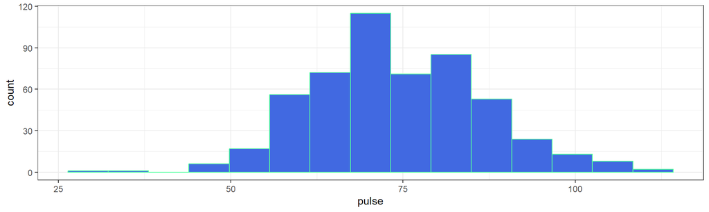

## Describing the Pulse Rates

How might we describe this distribution?

- What is the center?
- How much of a range around that center do we see? How spread out are the data?
- What is the shape of this distribution?
  - Is it symmetric, or is it skewed to the left or to the right?

(Histogram is replotted on the next slide)

## Histogram (with warning suppressed)

```r
ggplot(data = qsdat, aes(x = pulse)) +
    geom_histogram(bins = 15, fill = "royalblue", col = "seagreen1")
```

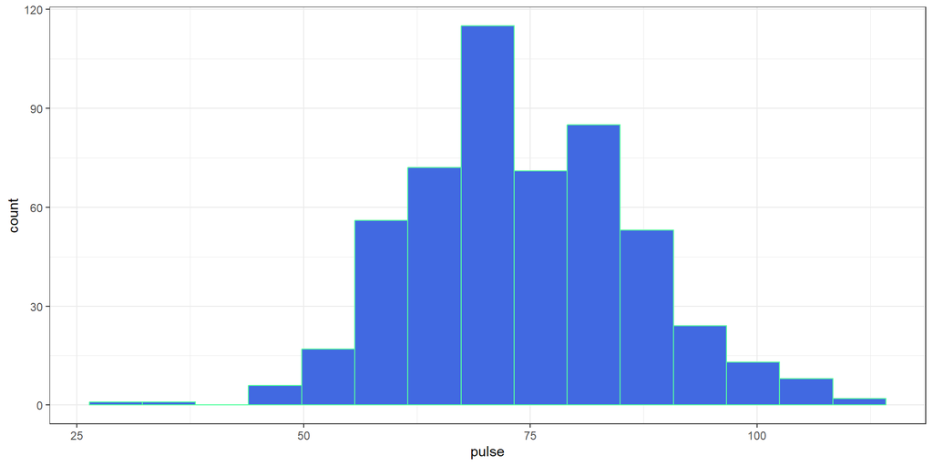

## Some Key Numerical Summaries

```r
qsdat |> select(pulse) |> summary()
```

```
     pulse
 Min.   : 30.00
 1st Qu.: 65.00
 Median : 72.00
 Mean   : 73.93
 3rd Qu.: 80.00
 Max.   :112.00
 NA's   :79
```

```r
length(qsdat$pulse)
```

```
[1] 603
```

```r
sd(qsdat$pulse, na.rm = TRUE)
```

```
[1] 12.43657
```

```r
mad(qsdat$pulse, na.rm = TRUE)
```

```
[1] 11.8608
```

- Do these summaries help us describe the data?

## Histogram, version 2

```r
dat1 <- qsdat |>
  filter(complete.cases(pulse))

ggplot(data = dat1, aes(x = pulse)) +
    geom_histogram(fill = "seagreen", col = "white", bins = 20) +
    labs(title = "Pulse Rates of Dr. Love's students",
         subtitle = "2014 - 2024",
         y = "Number of Students",
         x = "Pulse Rate (beats per minute)")
```

- How did we deal with missing data?
- How did we add axis labels and titles to the plot?
- What is the distinction between `fill` and `col`?
- How many bins should we use?

## Histogram, version 2

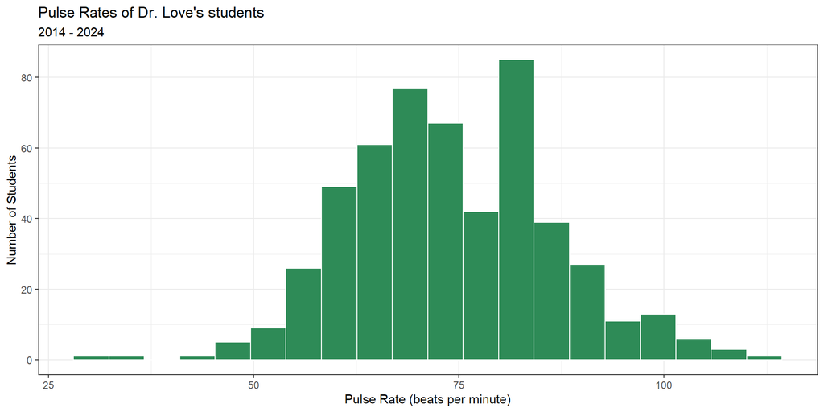

## Question 2

Does the distribution of student heights change over time?

(Plot shown on next slide)

```r
ggplot(qsdat, aes(x = year, y = height_in)) +
  geom_point(alpha = 0.7, color = "forestgreen")
```

## Question 2

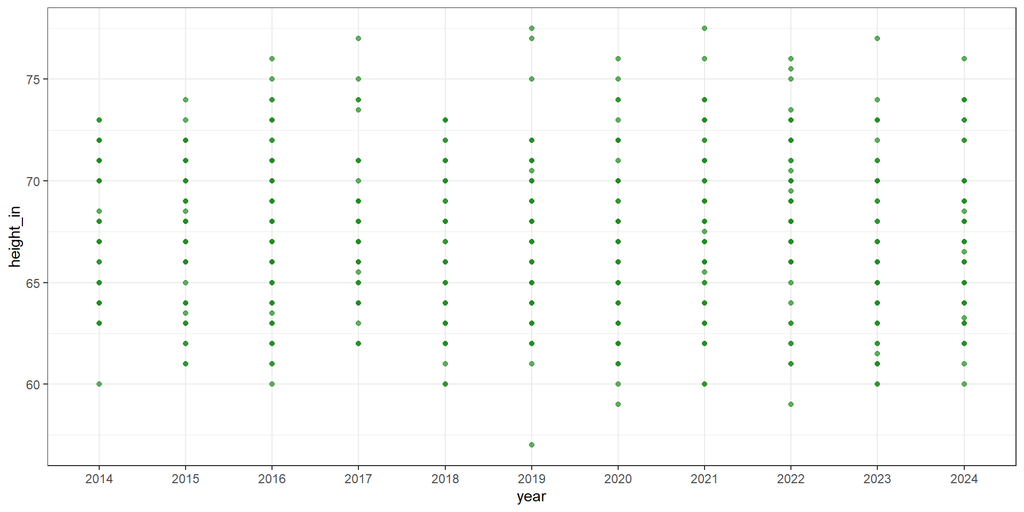

## Yearly Five-Number Summaries

```r
qsdat |>
    filter(complete.cases(height_in)) |>
    group_by(year) |>
    summarize(n = n(), min = min(height_in), q25 = quantile(height_in, 0.25),
              median = median(height_in), q75 = quantile(height_in, 0.75),
              max = max(height_in))
```

- What should this produce? (Results on next slide)

## Yearly Five-Number Summaries

```
# A tibble: 11 × 7
   year      n   min   q25 median   q75   max
   <fct> <int> <dbl> <dbl>  <dbl> <dbl> <dbl>
 1 2014     40    60  64.8   68    71    73
 2 2015     49    61  65     68    70    74
 3 2016     64    60  64     67    70    76
 4 2017     48    62  65     67    69    77
 5 2018     51    60  63     66    70    73
 6 2019     60    57  65     68    70    77.5
 7 2020     66    59  63     66    69.8  76
 8 2021     55    60  64.5   67.5  71    77.5
 9 2022     54    59  66     68.5  70.4  76
10 2023     53    60  64     65    69    77
11 2024     54    60  64     67    69.8  76
```

- Do these summaries change materially over time?
- What are these summaries, specifically?

## Five-Number Summary

- Key summaries based on percentiles / quantiles
  - minimum = 0th, maximum = 100th, median = 50th
  - quartiles (25th, 50th and 75th percentiles)
  - Range is maximum - minimum
  - IQR (inter-quartile range) is 75th - 25th percentile
- These summaries are generally more resistant to outliers than mean, standard deviation
- Form the elements of a boxplot (box-and-whisker plot)

## Boxplot of Heights by Year

```r
dat1 <- qsdat |>
    filter(complete.cases(height_in))

ggplot(data = dat1, aes(x = year, y = height_in)) +
    geom_boxplot() +
    labs(title = "Heights of Dr. Love's students, by year",
         subtitle = "2014 - 2024", x = "Year", y = "Height (in inches)")
```

- How did we deal with missing data here?

## Boxplot of Heights by Year

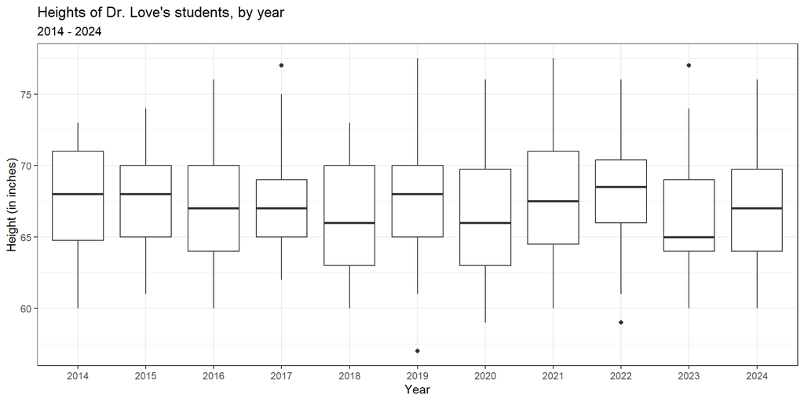

## Thinking about the Boxplot

- Box covers the middle half of the data (25th and 75th percentiles), and the solid line indicates the median
- Whiskers extend from the quartiles to the most extreme values that are not judged by **Tukey’s** “fences” method to be candidate outliers
  - Fences are drawn at 25th percentile - 1.5 IQR and 75th percentile + 1.5 IQR
- Are any values candidate outliers by this method?
- Was it important to change `year` to a factor earlier?

## Adding a Violin to the Boxplot

- When we’d like to better understand the shape of a distribution, we can amplify the boxplot.

```r
dat1 <- qsdat |>
    filter(complete.cases(height_in))

ggplot(data = dat1, aes(x = year, y = height_in)) +
    geom_violin() +
    geom_boxplot(aes(fill = year), width = 0.3) +
    guides(fill = "none") +
    scale_fill_viridis_d(alpha = 0.3) +
    labs(title = "Heights of Dr. Love's students, by year",
         subtitle = "2014 - 2024", x = "Year", y = "Height (in inches)")
```

## Adding a Violin to the Boxplot

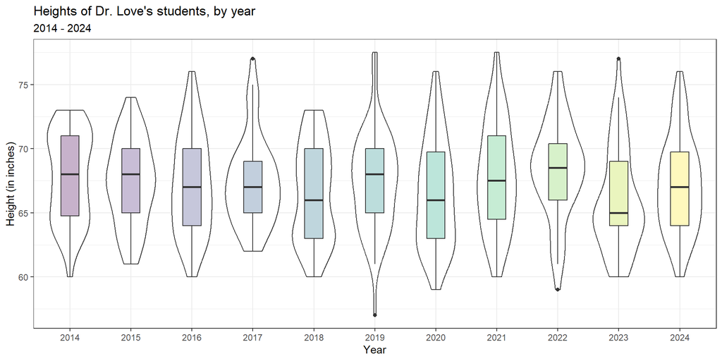

## Boxplot with Violin

- How did we change the boxplot when we added the violin?
- What would happen if we added the boxplot first and the violin second?
- What does `guides(fill = "none")` do?
- What does `scale_fill_viridis_d(alpha = 0.3)` do?

## Key Numerical Summaries

```r
qsdat |>
    filter(complete.cases(height_in)) |>
    group_by(year) |>
    summarize(n = n(), mean = mean(height_in), sd = sd(height_in),
              median = median(height_in), mad = mad(height_in))
```

```
# A tibble: 11 × 6
   year      n  mean    sd median   mad
   <fct> <int> <dbl> <dbl>  <dbl> <dbl>
 1 2014     40  67.8  3.46   68    4.45
 2 2015     49  67.3  3.32   68    2.97
 3 2016     64  67.2  3.86   67    4.45
 4 2017     48  67.4  3.46   67    2.97
 5 2018     51  66.5  3.81   66    4.45
 6 2019     60  67.4  3.83   68    4.45
 7 2020     66  66.4  4.09   66    4.45
 8 2021     55  67.8  4.13   67.5  5.19
 9 2022     54  68.4  3.74   68.5  3.71
10 2023     53  66.0  4.00   65    2.97
11 2024     54  67.2  3.70   67    4.45
```

## Question 3

Are the data on student heights in 2024 well described by a Normal distribution?

- Can we use a mean and standard deviation to describe the center and spread of the data effectively?

## A Normal distribution

This is a Normal (or Gaussian) distribution with mean 150 and standard deviation 30.

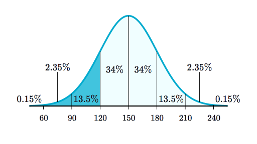

- A Normal distribution is completely specified by its mean and standard deviation. The “bell shape” doesn’t change.

## Summarizing Quantitative Data

If the data followed a Normal model,

- we would be justified in using the sample **mean** to describe the center, and
- in using the sample **standard deviation** to describe the spread (variation.)

But it is often the case that these measures aren’t robust enough, because the data show meaningful skew (asymmetry), or the data have lighter or heavier tails than a Normal model would predict.

## The Empirical Rule for Approximately Normal Distributions

If the data followed a Normal distribution,

- approximately 68% of the data would be within 1 SD of the mean,
- approximately 95% of the data would be within 2 SD of the mean, while
- essentially all (99.7%) of the data would be within 3 SD of the mean.

## Empirical Rule & 2024 Student Heights

```r
dat2 <- qsdat |>
  filter(complete.cases(height_in),
         year == "2024")

describe_distribution(dat2$height_in)
```

```
 Mean |   SD | IQR |          Range | Skewness | Kurtosis |  n | n_Missing
--------------------------------------------------------------------------
67.17 | 3.70 |   6 | [60.00, 76.00] |     0.35 |    -0.42 | 54 |         0
```

In 2024, we had 54 students whose `height_in` was available, with mean 67.2 inches (170.7 cm) and standard deviation 3.7 inches (9.4 cm).

Consider a picture of the data…

## Histogram of 2024 Student Heights

```r
dat2 <- qsdat |>
  filter(complete.cases(height_in)) |>
  filter(year == "2024")

ggplot(data = dat2, aes(x = height_in)) +
    geom_histogram(fill = "salmon", col = "white", binwidth = 1) +
    labs(title = "Heights of Dr. Love's students",
         subtitle = "2024 (n = 54 students with height data)",
         y = "Number of Students", x = "Height (inches)")
```

- How did we use the two `filter()` statements?
- Why might I have changed from specifying `bins` to `binwidth` here?

## Histogram of 2024 Student Heights

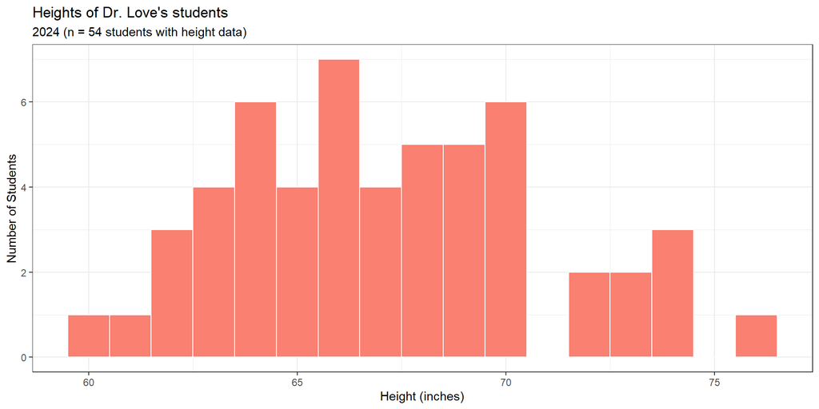

## Checking the 1-SD Empirical Rule

- Of the 54 students in 2024 with heights, how many were within 1 SD of the mean?
  - Mean = 67.2, SD = 3.7.
  - 67.2 - 3.7 = 63.5 inches and 67.2 + 3.7 = 70.9 inches

```r
qsdat |> filter(complete.cases(height_in)) |>
    filter(year == "2024") |>
    count(height_in >= 63.5 & height_in <= 70.9)
```

```
# A tibble: 2 × 2
  `height_in >= 63.5 & height_in <= 70.9`     n
  <lgl>                                   <int>
1 FALSE                                      17
2 TRUE                                       37
```

```r
37/(37+17)
```

```
[1] 0.6851852
```

## 2-SD Empirical Rule

- How many of the 54 `height_in` values gathered in 2024 were between 67.2 - 2(3.7) = 59.8 and 67.2 + 2(3.7) = 74.6 inches?

```r
qsdat |> filter(complete.cases(height_in)) |>
    filter(year == "2024") |>
    count(height_in >= 59.8 & height_in <= 74.6)
```

```
# A tibble: 2 × 2
  `height_in >= 59.8 & height_in <= 74.6`     n
  <lgl>                                   <int>
1 FALSE                                       1
2 TRUE                                       53
```

```r
53/(53+1)
```

```
[1] 0.9814815
```

## 3-SD Empirical Rule

- How many of the 54 `height_in` values gathered in 2024 were between 67.2 - 3(3.7) = 56.1 and 67.2 + 3(3.7) = 78.3 inches?

```r
qsdat |> filter(complete.cases(height_in)) |>
    filter(year == "2024") |>
    count(height_in >= 56.1 & height_in <= 78.3)
```

```
# A tibble: 1 × 2
  `height_in >= 56.1 & height_in <= 78.3`     n
  <lgl>                                   <int>
1 TRUE                                       54
```

```r
54/(54+0)
```

```
[1] 1
```

## Empirical Rule Table for 2024 data

- $\bar{x}$ = sample mean, $s$ = sample SD
- For `height_in`: $n$ = 54 with data, $\bar{x} = 67.2, s = 3.7$
- For `haircut`: $n$ = 53 with data, $\bar{x} = 37.9, s = 38.2$

| Range | “Normal” | `height_in` | `haircut` |
| --- | --- | --- | --- |
| $\bar{x} \pm s$ | ~68% | $\frac{37}{54}$ = 68.5% | $\frac{49}{53}$ = 92.4% |
| $\bar{x} \pm 2\times s$ | ~95% | $\frac{53}{54}$ = 98.1% | $\frac{50}{53}$ = 94.3% |
| $\bar{x} \pm 3\times s$ | ~99.7% | $\frac{54}{54}$ = 100% | $\frac{51}{53}$ = 96.2% |

## Boxplots of Height and Haircut Prices

```r
dat2 <- qsdat |> filter(complete.cases(height_in), year == "2024")

p2 <- ggplot(data = dat2, aes(x = "height (inches)", y = height_in)) +
  geom_violin() + geom_boxplot(width = 0.3, fill = "tomato") +
  labs(title = "Boxplot of 2024 Student Heights", x = "")

dat3 <- qsdat |> filter(complete.cases(haircut), year == "2024")

p3 <- ggplot(data = dat3, aes(x = "haircut ($)", y = haircut)) +
  geom_violin() + geom_boxplot(width = 0.3, fill = "dodgerblue") +
  labs(title = "Boxplot of 2024 Haircut Prices", x = "")

p2 + p3 +
  plot_annotation(title = "2024 Quick Survey Data")
```

- What is `width = 0.3` doing? How about the `x` options?
- What am I doing with `p2 + p3 + plot_annotation`?
- What should this look like?

## Boxplots of Height and Haircut Prices

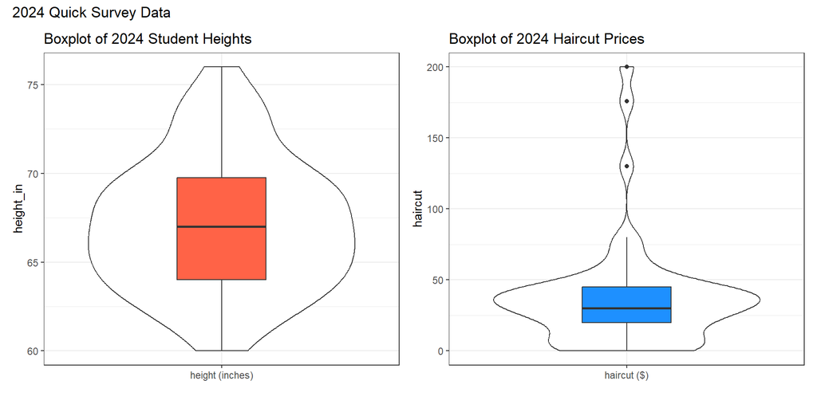

## Mean/SD vs. Median/MAD

If the data are approximately Normally distributed (like `height_in` and `pulse`) we can safely use the sample mean and standard deviation as summaries. If not “Normal”, then …

- The median is a more robust summary of the center.
- For spread, try the median absolute deviation (scaled to equal the standard deviation if the data are Normal)

| Measure | Median | Mean | MAD | Std. Dev. |
| --- | --- | --- | --- | --- |
| height_in | 67 | 67.2 | 4.5 | 3.7 |
| haircut | 30 | 37.9 | 22.2 | 38.2 |

## Question 4

Do tall people pay less for haircuts?

- Why might we think that they do, before we see the data?
- Convert our student heights from inches to centimeters…

```r
qsdat <- qsdat |> mutate(height_cm = height_in * 2.54)

qsdat |> select(student, height_in, height_cm) |> head()
```

```
# A tibble: 6 × 3
  student height_in height_cm
  <chr>       <dbl>     <dbl>
1 202401       63        160.
2 202402       69        175.
3 202403       66        168.
4 202404       68.5      174.
5 202405       62        157.
6 202406       64        163.
```

## A First Scatterplot

- We’ll include the straight line from a linear model, in red.

```r
dat4 <- qsdat |> filter(complete.cases(height_cm, haircut))

ggplot(dat4, aes(x = height_cm, y = haircut)) +
    geom_point(alpha = 0.3) +
    geom_smooth(method = "lm", col = "red",
                formula = y ~ x, se = TRUE) +
    labs(x = "Height (in cm)",
         y = "Price of last haircut (in $)",
         title = "Do taller people pay less for haircuts?")
```

## A First Scatterplot

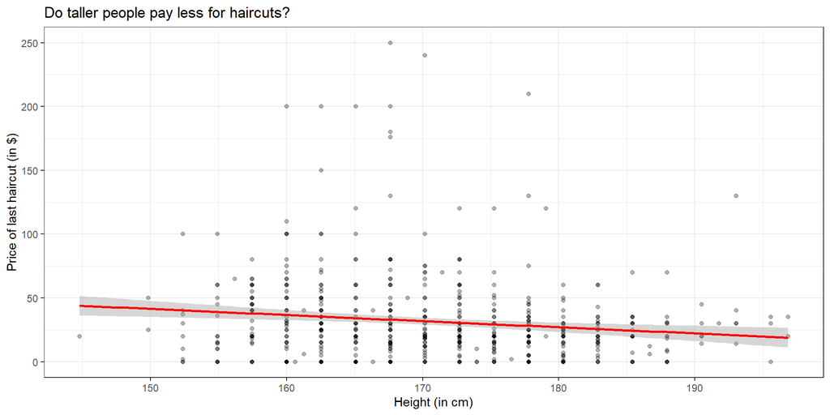

## What is the (Pearson) correlation of height and haircut price?

```r
dat4 <- qsdat |> filter(complete.cases(height_cm, haircut))

dat4 |>
    select(height_in, height_cm, haircut) |>
    cor()
```

```
           height_in  height_cm    haircut
height_in  1.0000000  1.0000000 -0.1394674
height_cm  1.0000000  1.0000000 -0.1394674
haircut   -0.1394674 -0.1394674  1.0000000
```

## What is the straight line regression model?

```r
dat4 <- qsdat |> filter(complete.cases(height_cm, haircut))

mod1 <- lm(haircut ~ height_cm, data = dat4)

mod1
```

```
Call:
lm(formula = haircut ~ height_cm, data = dat4)

Coefficients:
(Intercept)    height_cm
     113.46        -0.48
```

## Summarizing our model `mod1`

```r
model_parameters(mod1)
```

```
Parameter   | Coefficient |    SE |          95% CI | t(587) |      p
---------------------------------------------------------------------
(Intercept) |      113.46 | 24.06 | [66.22, 160.71] |   4.72 | < .001
height cm   |       -0.48 |  0.14 | [-0.76,  -0.20] |  -3.41 | < .001
```

Regression Equation is:

$$haircut = 113.46 - 0.48 (height_{cm}) + error$$

Our predicted `haircut` price for someone who is 170 cm (about 5 feet 7 inches) tall is…

$$haircut = 113.46 - 0.48 (170) = $31.86$$

## `lm` fit vs. `loess` smooth curve?

```r
dat4 <- qsdat |> filter(complete.cases(height_cm, haircut))

ggplot(dat4, aes(x = height_cm, y = haircut)) +
    geom_point(alpha = 0.5) +
    geom_smooth(method = "lm", col = "red",
                formula = y ~ x, se = FALSE) +
    geom_smooth(method = "loess", col = "blue",
                formula = y ~ x, se = FALSE) +
    labs(x = "Height (in cm)",
         y = "Price of last haircut (in $)",
         title = "Do taller people pay less for haircuts?")
```

- Does a linear model appear to fit these data well?
- Do taller people pay less for their haircuts?

## `lm` fit vs. `loess` smooth curve?

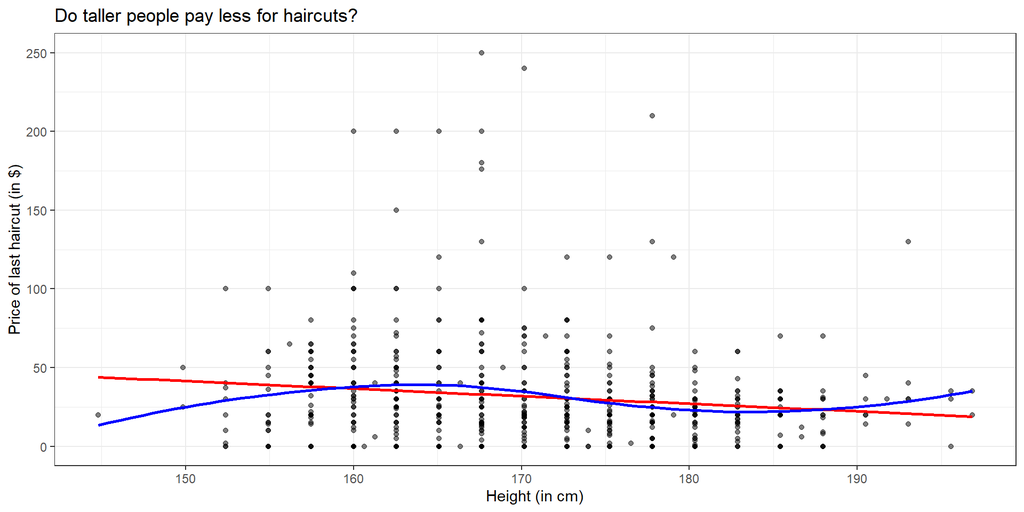

## Question 5

Do students have a more substantial tobacco history if they prefer to speak English or a language other than English?

```r
qsdat |> count(english, smoke)
```

```
# A tibble: 9 × 3
  english smoke     n
  <fct>   <fct> <int>
1 y       1       436
2 y       2        30
3 y       3         6
4 y       <NA>      1
5 n       1       116
6 n       2         3
7 n       3         4
8 <NA>    1         6
9 <NA>    <NA>      1
```

`smoke` codes (tobacco use): 1 = Never, 2 = Former, 3 = Current

## Restrict ourselves to 2024 data

- Do students in the 2024 class have a more substantial history of tobacco use if they prefer to speak a language other than English?

```r
dat5 <- qsdat |>
    filter(year == "2024") |>
    filter(complete.cases(english, smoke)) |>
    select(student, year, english, smoke)
summary(dat5)
```

```
   student               year    english smoke
 Length:54          2024   :54   y:46    1:51
 Class :character   2014   : 0   n: 8    2: 2
 Mode  :character   2015   : 0           3: 1
                    2016   : 0
                    2017   : 0
                    2018   : 0
                    (Other): 0
```

## Tabulating the categorical variables individually

```r
dat5 |> tabyl(english)
```

```
 english  n   percent
       y 46 0.8518519
       n  8 0.1481481
```

```r
dat5 |> tabyl(smoke) |> adorn_pct_formatting()
```

```
 smoke  n percent
     1 51   94.4%
     2  2    3.7%
     3  1    1.9%
```

- What does `adorn_pct_formatting()` do?

## Cross-Classification (2 rows $\times$ 3 columns)

```r
dat5 |> tabyl(english, smoke)
```

```
 english  1 2 3
       y 43 2 1
       n  8 0 0
```

## Recode the `smoke` levels to more meaningful names in `tobacco`

```r
dat5 <- dat5 |>
    mutate(tobacco = fct_recode(smoke,
            "Never" = "1", "Quit" = "2", "Current" = "3"))
```

### Check our work?

```r
dat5 |> count(smoke, tobacco)
```

```
# A tibble: 3 × 3
  smoke tobacco     n
  <fct> <fct>   <int>
1 1     Never      51
2 2     Quit        2
3 3     Current     1
```

- Everyone with `smoke` = 1 has `tobacco` as Never, etc.

## Restate the cross-tabulation

Now we’ll use this new variable, and this time, add row and column totals.

```r
dat5 |> tabyl(english, tobacco) |>
    adorn_totals(where = c("row", "col"))
```

```
 english Never Quit Current Total
       y    43    2       1    46
       n     8    0       0     8
   Total    51    2       1    54
```

- What can we conclude about this association?

## How about in 2014-2024?

```r
dat6 <- qsdat |>
  filter(complete.cases(english, smoke)) |>
  mutate(tobacco = fct_recode(smoke,
            "Never" = "1", "Quit" = "2", "Current" = "3"))

dat6 |>
  tabyl(english, tobacco) |>
  adorn_totals(where = c("row", "col"))
```

```
 english Never Quit Current Total
       y   436   30       6   472
       n   116    3       4   123
   Total   552   33      10   595
```

- Now, what is your conclusion?

## Next Time

Analyzing a (small) health dataset

## Cleaning up the temporary objects

```r
rm(mod1, p2, p3, dat1, dat2, dat2, dat3, dat4, dat5, dat6)

## this just leaves
## qsdat and quicksur_raw in my Global Environment
```

431 Class 03 | 2024-09-03 | https://thomaselove.github.io/431-2024/